# Introduction to Neural Networks: Bank Churn prediction

## Problem Statement

### Context

Businesses like banks which provide service have to worry about problem of 'Customer Churn' i.e. customers leaving and joining another service provider. It is important to understand which aspects of the service influence a customer's decision in this regard. Management can concentrate efforts on improvement of service, keeping in mind these priorities.

### Objective

You as a Data scientist with the bank need to build a neural network based classifier that can determine whether a customer will leave the bank or not in the next 6 months.

### Data Dictionary:

- CustomerId: Unique ID which is assigned to each customer
- Surname: Last name of the customer
- CreditScore: It defines the credit history of the customer.
- Geography: A customer’s location
- Gender: It defines the Gender of the customer
- Age: Age of the customer
- Tenure: Number of years for which the customer has been with the bank
- NumOfProducts: refers to the number of products that a customer has purchased through the bank.
- Balance: Account balance
- HasCrCard: It is a categorical variable which decides whether the customer has credit card or not.
- EstimatedSalary: Estimated salary
- isActiveMember: Is is a categorical variable which decides whether the customer is active member of the bank or not ( Active member in the sense, using bank products regularly, making transactions etc )
- Exited : whether or not the customer left the bank within six month. It can take two values **0=No ( Customer did not leave the bank )** 1=Yes ( Customer left the bank )

## Importing necessary libraries

```python
import numpy as np
import pandas as pd
import matplotlib.pyplot as plt
import seaborn as sns

from sklearn.model_selection import train_test_split, GridSearchCV
from sklearn.preprocessing import MinMaxScaler
from sklearn.metrics import confusion_matrix, accuracy_score, recall_score, precision_score

import tensorflow as tf
from tensorflow.keras.models import Sequential
from tensorflow.keras.layers import Dense, Dropout, Activation
from tensorflow.keras.wrappers.scikit_learn import KerasRegressor
from tensorflow.keras.metrics import Accuracy, Recall

from imblearn.over_sampling import SMOTE
```

## Loading the dataset

```python
data = pd.read_csv("Churn.csv")
data.head()
```

|  | RowNumber | CustomerId | Surname | CreditScore | Geography | Gender | Age | Tenure | Balance | NumOfProducts | HasCrCard | IsActiveMember | EstimatedSalary | Exited |
| --- | --- | --- | --- | --- | --- | --- | --- | --- | --- | --- | --- | --- | --- | --- |
| 0 | 1 | 15634602 | Hargrave | 619 | France | Female | 42 | 2 | 0.00 | 1 | 1 | 1 | 101348.88 | 1 |
| 1 | 2 | 15647311 | Hill | 608 | Spain | Female | 41 | 1 | 83807.86 | 1 | 0 | 1 | 112542.58 | 0 |
| 2 | 3 | 15619304 | Onio | 502 | France | Female | 42 | 8 | 159660.80 | 3 | 1 | 0 | 113931.57 | 1 |
| 3 | 4 | 15701354 | Boni | 699 | France | Female | 39 | 1 | 0.00 | 2 | 0 | 0 | 93826.63 | 0 |
| 4 | 5 | 15737888 | Mitchell | 850 | Spain | Female | 43 | 2 | 125510.82 | 1 | 1 | 1 | 79084.10 | 0 |

## Data Overview

```python
data.info()
```

```
<class 'pandas.core.frame.DataFrame'>
RangeIndex: 10000 entries, 0 to 9999
Data columns (total 14 columns):
 #   Column           Non-Null Count  Dtype
---  ------           --------------  -----
 0   RowNumber        10000 non-null  int64
 1   CustomerId       10000 non-null  int64
 2   Surname          10000 non-null  object
 3   CreditScore      10000 non-null  int64
 4   Geography        10000 non-null  object
 5   Gender           10000 non-null  object
 6   Age              10000 non-null  int64
 7   Tenure           10000 non-null  int64
 8   Balance          10000 non-null  float64
 9   NumOfProducts    10000 non-null  int64
 10  HasCrCard        10000 non-null  int64
 11  IsActiveMember   10000 non-null  int64
 12  EstimatedSalary  10000 non-null  float64
 13  Exited           10000 non-null  int64
dtypes: float64(2), int64(9), object(3)
memory usage: 1.1+ MB
```

```python
data.describe().T
```

|  | count | mean | std | min | 25% | 50% | 75% | max |
| --- | --- | --- | --- | --- | --- | --- | --- | --- |
| RowNumber | 10000.0 | 5.000500e+03 | 2886.895680 | 1.00 | 2500.75 | 5.000500e+03 | 7.500250e+03 | 10000.00 |
| CustomerId | 10000.0 | 1.569094e+07 | 71936.186123 | 15565701.00 | 15628528.25 | 1.569074e+07 | 1.575323e+07 | 15815690.00 |
| CreditScore | 10000.0 | 6.505288e+02 | 96.653299 | 350.00 | 584.00 | 6.520000e+02 | 7.180000e+02 | 850.00 |
| Age | 10000.0 | 3.892180e+01 | 10.487806 | 18.00 | 32.00 | 3.700000e+01 | 4.400000e+01 | 92.00 |
| Tenure | 10000.0 | 5.012800e+00 | 2.892174 | 0.00 | 3.00 | 5.000000e+00 | 7.000000e+00 | 10.00 |
| Balance | 10000.0 | 7.648589e+04 | 62397.405202 | 0.00 | 0.00 | 9.719854e+04 | 1.276442e+05 | 250898.09 |
| NumOfProducts | 10000.0 | 1.530200e+00 | 0.581654 | 1.00 | 1.00 | 1.000000e+00 | 2.000000e+00 | 4.00 |
| HasCrCard | 10000.0 | 7.055000e-01 | 0.455840 | 0.00 | 0.00 | 1.000000e+00 | 1.000000e+00 | 1.00 |
| IsActiveMember | 10000.0 | 5.151000e-01 | 0.499797 | 0.00 | 0.00 | 1.000000e+00 | 1.000000e+00 | 1.00 |
| EstimatedSalary | 10000.0 | 1.000902e+05 | 57510.492818 | 11.58 | 51002.11 | 1.001939e+05 | 1.493882e+05 | 199992.48 |
| Exited | 10000.0 | 2.037000e-01 | 0.402769 | 0.00 | 0.00 | 0.000000e+00 | 0.000000e+00 | 1.00 |

```python
data.isna().sum()
```

```
RowNumber          0
CustomerId         0
Surname            0
CreditScore        0
Geography          0
Gender             0
Age                0
Tenure             0
Balance            0
NumOfProducts      0
HasCrCard          0
IsActiveMember     0
EstimatedSalary    0
Exited             0
dtype: int64
```

While no NaNs were reported, this doesn't mean there weren't some irregular answers. Let's check out the non-numeric variables and see if there's something strange.

```python
for col in data[['Surname', 'Geography', 'Gender']]:
    print (data[col].value_counts())
```

```
Smith          32
Martin         29
Scott          29
Walker         28
Brown          26
               ..
Nazarova        1
Ecuyer          1
Burbidge        1
Winters         1
Arkwookerum     1
Name: Surname, Length: 2932, dtype: int64
France     5014
Germany    2509
Spain      2477
Name: Geography, dtype: int64
Male      5457
Female    4543
Name: Gender, dtype: int64
```

Nothing unusual here, too. I could go through the list of all the Surnames, but I don't think that's worth the time. We'll probably not even include this feature in our model.

## Exploratory Data Analysis

First thing I want to know is about the target variable. Is it imbalanced?

```python
data['Exited'].value_counts()
```

```
0    7963
1    2037
Name: Exited, dtype: int64
```

It does appear imbalanced with the majority of rows being non-exiting customers. This tells me a few things:

- A model that predicts "zero only" will be about 80% accurate. That is the low bar for performance. Any model will have to have better than 80% accuracy to be an improvement.
- We should use Recall as our prioritized performance metric since we want to optimize the number of exits we catch.
- It might be helpful to rebalance our training data with techniques such as SMOTE.

**Questions**:

1. What is the distribution of the credit score of customers? Are there any noticeable patterns or outliers in the distribution?

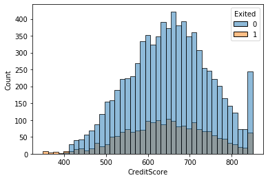

```python
sns.histplot(data=data,
            x="CreditScore",
            hue="Exited")
```

The distribution looks normal except for all the members that would be above 850 are capped at 850. This is because 850 is the maximum credit score.

The distribution looks mostly similar regardless of whether they were an exited customer or not.

1. How many active members are there with the bank?

```python
print(f"There are {data['IsActiveMember'].sum()} active members with the bank.")
```

```
There are 5151 active members with the bank.
```

1. How are the different customer attributes correlated to each other?

Who doesn't love a Pair Plot?

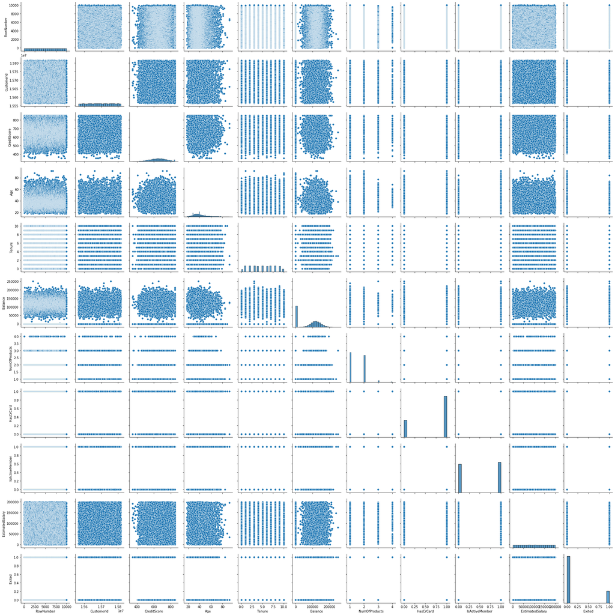

```python
sns.pairplot(data)
```

These pair plots show very weak correlation across the board.

1. Who is churning more when compared to males and females?

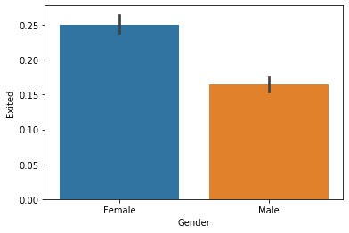

```python
sns.barplot(data=data, x="Gender", y="Exited")
```

More churn with females than with males.

1. Customers from which geographical part are churning more?

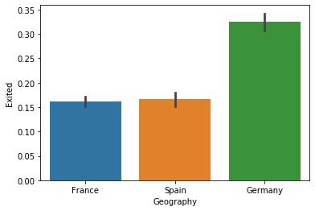

```python
sns.barplot(data=data, x="Geography", y="Exited")
```

More churn with Germans than the French or Spanish.

## Data Preprocessing

- Missing value treatment
- Feature engineering (if needed)
- Outlier detection and treatment (if needed)
- Preparing data for modeling
- Any other preprocessing steps (if needed)

RowNumber, CustomerID, and Surname should have no relevance to the target variable, so these will all be removed from the training data.

Furthermore, we can one-hot encode the categorical features, Gender and Geography.

Finally, we will split the data into train and test datasets and scale the numerical variables separately.

```python
#Drop meaningless features
df = data.drop("RowNumber", axis=1
).drop("CustomerId", axis=1
).drop("Surname", axis=1)

#One-hot encode categorical variables
df = df.join(pd.get_dummies(df['Gender'])
).join(pd.get_dummies(df['Geography'])
).drop("Gender", axis=1
).drop("Geography", axis=1
)

#Split target variable from rest of dataset
features = df.drop("Exited", axis=1)
target = df['Exited']

#Split dataset into training and testing sets
X_train, X_test, y_train, y_test =  train_test_split(features, target, test_size=0.25, random_state=1)

#Scale datasets to work with normalized numbers
scaler = MinMaxScaler()
X_train = scaler.fit_transform(X_train)
X_test = scaler.fit_transform(X_test)

y_train = np.array(y_train)
y_test = np.array(y_test)
```

## Model Building

### Model Evaluation Criterion

Sometimes you really want to focus on recall, precision, or overall accuracy, depending on the business implications of type I or type II errors. In this case, what would the bank do if they detect a customer might exit? Offer some deal to keep them? That has costs.

I believe the best application of this model will be to project the correct number of customers the bank will have some time in the future. Knowing that they'll keep, let's say, 80% of their customers will allow them to create accurage budgets and plans even in the future. They have to be aware if that number can change, though. Say in a certain quarter that the model says that 30% of their customers are predicted to leave within six months. That may allow them to adjust their future budget downward and avoid being caught by surprise.

Because we care about the number of total customers that both stay and exit, we will prioritize accuracy as our optimized metric.

### Model Building: Neural Network

Let's begin with a simple network with no fancy flairs: just 2 hidden layers and an output layer.

```python
#Create a model with two hidden layers and one output node
model_nn = Sequential()
model_nn.add(Dense(64, activation='relu', input_shape=(X_test.shape[1],)))
model_nn.add(Dense(64, activation='relu'))
model_nn.add(Dense(1, activation='sigmoid')) #sigmoid is best for binary classification
```

### Model Building: Neural Network model with Adam Optimizer

```python
model_nn.compile(loss='binary_crossentropy', optimizer='adam', metrics=['accuracy'])
model_nn.summary()
```

```
Model: "sequential"
_________________________________________________________________
Layer (type)                 Output Shape              Param #
=================================================================
dense (Dense)                (None, 64)                896
_________________________________________________________________
dense_1 (Dense)              (None, 64)                4160
_________________________________________________________________
dense_2 (Dense)              (None, 1)                 65
=================================================================
Total params: 5,121
Trainable params: 5,121
Non-trainable params: 0
_________________________________________________________________
```

```python
history_1 = model_nn.fit(
    X_train,
    y_train,
    validation_split=0.1,
    epochs=150,
    verbose=2
)
```

```
Train on 6750 samples, validate on 750 samples
6750/6750 - 1s - loss: 0.4796 - accuracy: 0.8000 - val_loss: 0.4813 - val_accuracy: 0.7853
6750/6750 - 0s - loss: 0.4388 - accuracy: 0.8114 - val_loss: 0.4735 - val_accuracy: 0.7893
6750/6750 - 0s - loss: 0.4249 - accuracy: 0.8170 - val_loss: 0.4685 - val_accuracy: 0.8013
6750/6750 - 0s - loss: 0.4112 - accuracy: 0.8256 - val_loss: 0.4598 - val_accuracy: 0.7973
6750/6750 - 0s - loss: 0.3996 - accuracy: 0.8317 - val_loss: 0.4392 - val_accuracy: 0.8080
6750/6750 - 0s - loss: 0.3795 - accuracy: 0.8415 - val_loss: 0.4041 - val_accuracy: 0.8360
6750/6750 - 0s - loss: 0.3665 - accuracy: 0.8464 - val_loss: 0.3880 - val_accuracy: 0.8267
6750/6750 - 0s - loss: 0.3550 - accuracy: 0.8554 - val_loss: 0.3891 - val_accuracy: 0.8253
6750/6750 - 0s - loss: 0.3510 - accuracy: 0.8551 - val_loss: 0.3795 - val_accuracy: 0.8360
6750/6750 - 0s - loss: 0.3480 - accuracy: 0.8566 - val_loss: 0.3719 - val_accuracy: 0.8293
6750/6750 - 0s - loss: 0.3464 - accuracy: 0.8572 - val_loss: 0.3695 - val_accuracy: 0.8347
6750/6750 - 0s - loss: 0.3431 - accuracy: 0.8606 - val_loss: 0.3764 - val_accuracy: 0.8387
6750/6750 - 0s - loss: 0.3423 - accuracy: 0.8576 - val_loss: 0.3665 - val_accuracy: 0.8333
6750/6750 - 0s - loss: 0.3411 - accuracy: 0.8588 - val_loss: 0.3647 - val_accuracy: 0.8373
6750/6750 - 0s - loss: 0.3407 - accuracy: 0.8599 - val_loss: 0.3693 - val_accuracy: 0.8360
6750/6750 - 0s - loss: 0.3406 - accuracy: 0.8593 - val_loss: 0.3708 - val_accuracy: 0.8360
6750/6750 - 0s - loss: 0.3374 - accuracy: 0.8594 - val_loss: 0.3659 - val_accuracy: 0.8373
6750/6750 - 0s - loss: 0.3351 - accuracy: 0.8606 - val_loss: 0.3703 - val_accuracy: 0.8307
6750/6750 - 0s - loss: 0.3372 - accuracy: 0.8622 - val_loss: 0.3707 - val_accuracy: 0.8387
6750/6750 - 0s - loss: 0.3332 - accuracy: 0.8616 - val_loss: 0.3690 - val_accuracy: 0.8347
6750/6750 - 0s - loss: 0.3349 - accuracy: 0.8610 - val_loss: 0.3726 - val_accuracy: 0.8320
6750/6750 - 0s - loss: 0.3324 - accuracy: 0.8606 - val_loss: 0.3694 - val_accuracy: 0.8427
6750/6750 - 0s - loss: 0.3315 - accuracy: 0.8641 - val_loss: 0.3787 - val_accuracy: 0.8347
6750/6750 - 0s - loss: 0.3322 - accuracy: 0.8643 - val_loss: 0.3738 - val_accuracy: 0.8320
6750/6750 - 0s - loss: 0.3297 - accuracy: 0.8644 - val_loss: 0.3635 - val_accuracy: 0.8387
6750/6750 - 0s - loss: 0.3290 - accuracy: 0.8655 - val_loss: 0.3618 - val_accuracy: 0.8400
6750/6750 - 0s - loss: 0.3285 - accuracy: 0.8633 - val_loss: 0.3775 - val_accuracy: 0.8360
6750/6750 - 0s - loss: 0.3272 - accuracy: 0.8665 - val_loss: 0.3717 - val_accuracy: 0.8320
6750/6750 - 0s - loss: 0.3269 - accuracy: 0.8649 - val_loss: 0.3637 - val_accuracy: 0.8440
6750/6750 - 0s - loss: 0.3257 - accuracy: 0.8658 - val_loss: 0.3665 - val_accuracy: 0.8333
6750/6750 - 0s - loss: 0.3245 - accuracy: 0.8670 - val_loss: 0.3684 - val_accuracy: 0.8400
6750/6750 - 0s - loss: 0.3241 - accuracy: 0.8647 - val_loss: 0.3636 - val_accuracy: 0.8347
6750/6750 - 0s - loss: 0.3261 - accuracy: 0.8662 - val_loss: 0.3636 - val_accuracy: 0.8413
6750/6750 - 0s - loss: 0.3220 - accuracy: 0.8664 - val_loss: 0.3616 - val_accuracy: 0.8440
6750/6750 - 0s - loss: 0.3235 - accuracy: 0.8661 - val_loss: 0.3616 - val_accuracy: 0.8427
6750/6750 - 0s - loss: 0.3197 - accuracy: 0.8698 - val_loss: 0.3677 - val_accuracy: 0.8360
6750/6750 - 0s - loss: 0.3204 - accuracy: 0.8695 - val_loss: 0.3634 - val_accuracy: 0.8427
6750/6750 - 0s - loss: 0.3200 - accuracy: 0.8670 - val_loss: 0.3796 - val_accuracy: 0.8360
6750/6750 - 0s - loss: 0.3186 - accuracy: 0.8701 - val_loss: 0.3643 - val_accuracy: 0.8400
```

[output cut: 96 more lines]

```
6750/6750 - 0s - loss: 0.2642 - accuracy: 0.8904 - val_loss: 0.4088 - val_accuracy: 0.8427
6750/6750 - 0s - loss: 0.2630 - accuracy: 0.8907 - val_loss: 0.3944 - val_accuracy: 0.8453
6750/6750 - 0s - loss: 0.2622 - accuracy: 0.8881 - val_loss: 0.4006 - val_accuracy: 0.8347
6750/6750 - 0s - loss: 0.2605 - accuracy: 0.8901 - val_loss: 0.3988 - val_accuracy: 0.8320
6750/6750 - 0s - loss: 0.2591 - accuracy: 0.8905 - val_loss: 0.3937 - val_accuracy: 0.8427
6750/6750 - 0s - loss: 0.2581 - accuracy: 0.8917 - val_loss: 0.4063 - val_accuracy: 0.8373
6750/6750 - 0s - loss: 0.2585 - accuracy: 0.8929 - val_loss: 0.4231 - val_accuracy: 0.8387
6750/6750 - 0s - loss: 0.2592 - accuracy: 0.8917 - val_loss: 0.4010 - val_accuracy: 0.8440
6750/6750 - 0s - loss: 0.2591 - accuracy: 0.8923 - val_loss: 0.3968 - val_accuracy: 0.8440
6750/6750 - 0s - loss: 0.2595 - accuracy: 0.8917 - val_loss: 0.3976 - val_accuracy: 0.8373
6750/6750 - 0s - loss: 0.2563 - accuracy: 0.8904 - val_loss: 0.4020 - val_accuracy: 0.8280
6750/6750 - 0s - loss: 0.2561 - accuracy: 0.8914 - val_loss: 0.4167 - val_accuracy: 0.8387
6750/6750 - 0s - loss: 0.2564 - accuracy: 0.8920 - val_loss: 0.4028 - val_accuracy: 0.8467
6750/6750 - 0s - loss: 0.2547 - accuracy: 0.8920 - val_loss: 0.4084 - val_accuracy: 0.8360
6750/6750 - 0s - loss: 0.2553 - accuracy: 0.8933 - val_loss: 0.3997 - val_accuracy: 0.8333
```

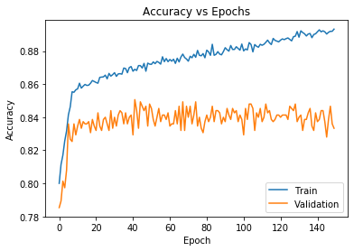

```python
plt.plot(history_1.history['accuracy'])
plt.plot(history_1.history['val_accuracy'])
plt.title('Accuracy vs Epochs')
plt.ylabel('Accuracy')
plt.xlabel('Epoch')
plt.legend(['Train', 'Validation'], loc='lower right')
plt.show()
```

### Model Improvement: Neural Network model with Dropout

```python
#Add dropout to each hidden layer
model_drop = Sequential()
model_drop.add(Dense(64, activation='relu', input_shape=(X_test.shape[1],)))
model_drop.add(Dropout(0.5))
model_drop.add(Dense(64, activation='relu'))
model_drop.add(Dropout(0.5))
model_drop.add(Dense(1, activation='sigmoid'))

model_drop.compile(loss='binary_crossentropy', optimizer='adam', metrics = ['accuracy'])
model_drop.summary()
```

```
Model: "sequential_2"
_________________________________________________________________
Layer (type)                 Output Shape              Param #
=================================================================
dense_6 (Dense)              (None, 64)                896
_________________________________________________________________
dropout_2 (Dropout)          (None, 64)                0
_________________________________________________________________
dense_7 (Dense)              (None, 64)                4160
_________________________________________________________________
dropout_3 (Dropout)          (None, 64)                0
_________________________________________________________________
dense_8 (Dense)              (None, 1)                 65
=================================================================
Total params: 5,121
Trainable params: 5,121
Non-trainable params: 0
_________________________________________________________________
```

```python
history_2 = model_drop.fit(
    X_train,
    y_train,
    validation_split=0.1,
    epochs=150,
    verbose=2
)
```

```
Train on 6750 samples, validate on 750 samples
6750/6750 - 1s - loss: 0.5129 - accuracy: 0.7929 - val_loss: 0.4948 - val_accuracy: 0.7773
6750/6750 - 0s - loss: 0.4752 - accuracy: 0.8004 - val_loss: 0.4850 - val_accuracy: 0.7773
6750/6750 - 0s - loss: 0.4692 - accuracy: 0.7999 - val_loss: 0.4819 - val_accuracy: 0.7773
6750/6750 - 0s - loss: 0.4595 - accuracy: 0.8028 - val_loss: 0.4764 - val_accuracy: 0.7787
6750/6750 - 0s - loss: 0.4523 - accuracy: 0.8021 - val_loss: 0.4795 - val_accuracy: 0.7840
6750/6750 - 0s - loss: 0.4455 - accuracy: 0.8081 - val_loss: 0.4601 - val_accuracy: 0.7920
6750/6750 - 0s - loss: 0.4354 - accuracy: 0.8096 - val_loss: 0.4486 - val_accuracy: 0.8133
6750/6750 - 0s - loss: 0.4261 - accuracy: 0.8167 - val_loss: 0.4346 - val_accuracy: 0.8080
6750/6750 - 0s - loss: 0.4189 - accuracy: 0.8270 - val_loss: 0.4263 - val_accuracy: 0.8147
6750/6750 - 0s - loss: 0.4047 - accuracy: 0.8344 - val_loss: 0.4099 - val_accuracy: 0.8320
6750/6750 - 0s - loss: 0.3992 - accuracy: 0.8335 - val_loss: 0.3999 - val_accuracy: 0.8360
6750/6750 - 0s - loss: 0.3948 - accuracy: 0.8400 - val_loss: 0.3986 - val_accuracy: 0.8347
6750/6750 - 0s - loss: 0.3964 - accuracy: 0.8357 - val_loss: 0.4005 - val_accuracy: 0.8293
6750/6750 - 0s - loss: 0.3949 - accuracy: 0.8421 - val_loss: 0.4063 - val_accuracy: 0.8267
6750/6750 - 0s - loss: 0.3938 - accuracy: 0.8385 - val_loss: 0.3931 - val_accuracy: 0.8387
6750/6750 - 0s - loss: 0.3847 - accuracy: 0.8436 - val_loss: 0.3893 - val_accuracy: 0.8333
6750/6750 - 0s - loss: 0.3867 - accuracy: 0.8394 - val_loss: 0.3872 - val_accuracy: 0.8387
6750/6750 - 0s - loss: 0.3843 - accuracy: 0.8441 - val_loss: 0.3856 - val_accuracy: 0.8240
6750/6750 - 0s - loss: 0.3806 - accuracy: 0.8446 - val_loss: 0.3852 - val_accuracy: 0.8347
6750/6750 - 0s - loss: 0.3775 - accuracy: 0.8427 - val_loss: 0.3851 - val_accuracy: 0.8333
6750/6750 - 0s - loss: 0.3765 - accuracy: 0.8493 - val_loss: 0.3800 - val_accuracy: 0.8333
6750/6750 - 0s - loss: 0.3776 - accuracy: 0.8470 - val_loss: 0.3761 - val_accuracy: 0.8387
6750/6750 - 0s - loss: 0.3730 - accuracy: 0.8487 - val_loss: 0.3767 - val_accuracy: 0.8400
6750/6750 - 0s - loss: 0.3766 - accuracy: 0.8453 - val_loss: 0.3796 - val_accuracy: 0.8413
6750/6750 - 0s - loss: 0.3685 - accuracy: 0.8505 - val_loss: 0.3792 - val_accuracy: 0.8360
6750/6750 - 0s - loss: 0.3697 - accuracy: 0.8481 - val_loss: 0.3771 - val_accuracy: 0.8387
6750/6750 - 0s - loss: 0.3698 - accuracy: 0.8473 - val_loss: 0.3766 - val_accuracy: 0.8387
6750/6750 - 0s - loss: 0.3702 - accuracy: 0.8480 - val_loss: 0.3757 - val_accuracy: 0.8427
6750/6750 - 0s - loss: 0.3696 - accuracy: 0.8492 - val_loss: 0.3733 - val_accuracy: 0.8387
6750/6750 - 0s - loss: 0.3655 - accuracy: 0.8527 - val_loss: 0.3761 - val_accuracy: 0.8360
6750/6750 - 0s - loss: 0.3603 - accuracy: 0.8538 - val_loss: 0.3701 - val_accuracy: 0.8360
6750/6750 - 0s - loss: 0.3670 - accuracy: 0.8479 - val_loss: 0.3720 - val_accuracy: 0.8360
6750/6750 - 0s - loss: 0.3670 - accuracy: 0.8499 - val_loss: 0.3700 - val_accuracy: 0.8413
6750/6750 - 0s - loss: 0.3669 - accuracy: 0.8507 - val_loss: 0.3704 - val_accuracy: 0.8373
6750/6750 - 0s - loss: 0.3650 - accuracy: 0.8529 - val_loss: 0.3697 - val_accuracy: 0.8360
6750/6750 - 0s - loss: 0.3638 - accuracy: 0.8547 - val_loss: 0.3725 - val_accuracy: 0.8333
6750/6750 - 0s - loss: 0.3611 - accuracy: 0.8523 - val_loss: 0.3695 - val_accuracy: 0.8307
6750/6750 - 0s - loss: 0.3640 - accuracy: 0.8533 - val_loss: 0.3701 - val_accuracy: 0.8333
6750/6750 - 0s - loss: 0.3620 - accuracy: 0.8566 - val_loss: 0.3666 - val_accuracy: 0.8400
```

[output cut: 96 more lines]

```
6750/6750 - 0s - loss: 0.3386 - accuracy: 0.8631 - val_loss: 0.3591 - val_accuracy: 0.8347
6750/6750 - 0s - loss: 0.3404 - accuracy: 0.8647 - val_loss: 0.3604 - val_accuracy: 0.8347
6750/6750 - 0s - loss: 0.3382 - accuracy: 0.8639 - val_loss: 0.3607 - val_accuracy: 0.8333
6750/6750 - 0s - loss: 0.3380 - accuracy: 0.8600 - val_loss: 0.3619 - val_accuracy: 0.8347
6750/6750 - 0s - loss: 0.3370 - accuracy: 0.8631 - val_loss: 0.3609 - val_accuracy: 0.8293
6750/6750 - 0s - loss: 0.3379 - accuracy: 0.8609 - val_loss: 0.3621 - val_accuracy: 0.8320
6750/6750 - 0s - loss: 0.3314 - accuracy: 0.8668 - val_loss: 0.3603 - val_accuracy: 0.8320
6750/6750 - 0s - loss: 0.3376 - accuracy: 0.8600 - val_loss: 0.3619 - val_accuracy: 0.8293
6750/6750 - 0s - loss: 0.3377 - accuracy: 0.8597 - val_loss: 0.3593 - val_accuracy: 0.8333
6750/6750 - 0s - loss: 0.3405 - accuracy: 0.8622 - val_loss: 0.3596 - val_accuracy: 0.8320
6750/6750 - 0s - loss: 0.3389 - accuracy: 0.8633 - val_loss: 0.3610 - val_accuracy: 0.8347
6750/6750 - 0s - loss: 0.3348 - accuracy: 0.8647 - val_loss: 0.3623 - val_accuracy: 0.8307
6750/6750 - 0s - loss: 0.3388 - accuracy: 0.8637 - val_loss: 0.3701 - val_accuracy: 0.8347
6750/6750 - 0s - loss: 0.3367 - accuracy: 0.8668 - val_loss: 0.3599 - val_accuracy: 0.8360
6750/6750 - 0s - loss: 0.3430 - accuracy: 0.8647 - val_loss: 0.3655 - val_accuracy: 0.8320
```

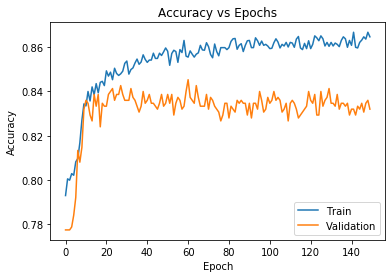

```python
plt.plot(history_2.history['accuracy'])
plt.plot(history_2.history['val_accuracy'])
plt.title('Accuracy vs Epochs')
plt.ylabel('Accuracy')
plt.xlabel('Epoch')
plt.legend(['Train', 'Validation'], loc='lower right')
plt.show()
```

### Model Improvement: Neural Network model with Hyperparameter tuning

```python
def buildModel(optimizer, hidden_layers, hidden_layer_size, dropout):
    model = Sequential()

    for i in range(hidden_layers):
        model.add(Dense(hidden_layer_size, activation='relu'))
        model.add(Dropout(dropout))

    model.add(Dense(1, activation='sigmoid'))
    model.compile(loss='binary_crossentropy', optimizer=optimizer, metrics=['accuracy'])

    return model
```

```python
model = KerasRegressor(build_fn = buildModel)

parameters = {
    'batch_size': [16, 32],
    'optimizer': ['adam', 'rmsprop'],
    'hidden_layers': [2, 3],
    'hidden_layer_size': [16, 32],
    'dropout': [0, 0.5]
}

grid_search = GridSearchCV(estimator = model,
                           param_grid = parameters,
                           scoring = 'neg_mean_absolute_error',
                           cv = 5)
grid_search = grid_search.fit(X_train, y_train, verbose = 0)
```

```python
best_parameters = grid_search.best_params_
best_score = grid_search.best_score_

print("Best Parameters: " + str(best_parameters))
```

```
Best Parameters: {'batch_size': 16, 'dropout': 0, 'hidden_layer_size': 32, 'hidden_layers': 3, 'optimizer': 'rmsprop'}
```

```python
best = buildModel("rmsprop", 3, 32, 0)
history_best = best.fit(
    X_train,
    y_train,
    batch_size = 16,
    validation_split=0.1,
    epochs=150,
    verbose=2
)
```

```
Train on 6750 samples, validate on 750 samples
6750/6750 - 1s - loss: 0.4729 - accuracy: 0.8001 - val_loss: 0.4912 - val_accuracy: 0.7840
6750/6750 - 0s - loss: 0.4441 - accuracy: 0.8092 - val_loss: 0.4720 - val_accuracy: 0.7947
6750/6750 - 0s - loss: 0.4286 - accuracy: 0.8167 - val_loss: 0.4559 - val_accuracy: 0.8133
6750/6750 - 0s - loss: 0.4175 - accuracy: 0.8215 - val_loss: 0.4534 - val_accuracy: 0.8067
6750/6750 - 0s - loss: 0.4054 - accuracy: 0.8305 - val_loss: 0.4360 - val_accuracy: 0.8133
6750/6750 - 0s - loss: 0.3889 - accuracy: 0.8390 - val_loss: 0.4145 - val_accuracy: 0.8213
6750/6750 - 0s - loss: 0.3755 - accuracy: 0.8467 - val_loss: 0.3955 - val_accuracy: 0.8320
6750/6750 - 0s - loss: 0.3652 - accuracy: 0.8492 - val_loss: 0.3884 - val_accuracy: 0.8307
6750/6750 - 0s - loss: 0.3586 - accuracy: 0.8535 - val_loss: 0.3957 - val_accuracy: 0.8320
6750/6750 - 0s - loss: 0.3563 - accuracy: 0.8560 - val_loss: 0.3818 - val_accuracy: 0.8307
6750/6750 - 0s - loss: 0.3521 - accuracy: 0.8594 - val_loss: 0.3884 - val_accuracy: 0.8253
6750/6750 - 0s - loss: 0.3496 - accuracy: 0.8559 - val_loss: 0.3831 - val_accuracy: 0.8320
6750/6750 - 0s - loss: 0.3501 - accuracy: 0.8575 - val_loss: 0.3850 - val_accuracy: 0.8400
6750/6750 - 0s - loss: 0.3468 - accuracy: 0.8596 - val_loss: 0.3825 - val_accuracy: 0.8373
6750/6750 - 0s - loss: 0.3460 - accuracy: 0.8575 - val_loss: 0.3833 - val_accuracy: 0.8360
6750/6750 - 0s - loss: 0.3445 - accuracy: 0.8624 - val_loss: 0.4026 - val_accuracy: 0.8347
6750/6750 - 0s - loss: 0.3425 - accuracy: 0.8606 - val_loss: 0.4005 - val_accuracy: 0.8360
6750/6750 - 0s - loss: 0.3409 - accuracy: 0.8641 - val_loss: 0.3869 - val_accuracy: 0.8347
6750/6750 - 0s - loss: 0.3409 - accuracy: 0.8606 - val_loss: 0.3916 - val_accuracy: 0.8267
6750/6750 - 0s - loss: 0.3396 - accuracy: 0.8644 - val_loss: 0.3776 - val_accuracy: 0.8413
6750/6750 - 0s - loss: 0.3397 - accuracy: 0.8619 - val_loss: 0.3770 - val_accuracy: 0.8280
6750/6750 - 0s - loss: 0.3375 - accuracy: 0.8640 - val_loss: 0.3764 - val_accuracy: 0.8347
6750/6750 - 0s - loss: 0.3365 - accuracy: 0.8622 - val_loss: 0.3825 - val_accuracy: 0.8320
6750/6750 - 0s - loss: 0.3366 - accuracy: 0.8664 - val_loss: 0.3820 - val_accuracy: 0.8333
6750/6750 - 0s - loss: 0.3363 - accuracy: 0.8637 - val_loss: 0.3766 - val_accuracy: 0.8387
6750/6750 - 0s - loss: 0.3350 - accuracy: 0.8634 - val_loss: 0.3880 - val_accuracy: 0.8333
6750/6750 - 0s - loss: 0.3363 - accuracy: 0.8630 - val_loss: 0.3835 - val_accuracy: 0.8333
6750/6750 - 0s - loss: 0.3350 - accuracy: 0.8649 - val_loss: 0.3909 - val_accuracy: 0.8427
6750/6750 - 0s - loss: 0.3347 - accuracy: 0.8644 - val_loss: 0.4076 - val_accuracy: 0.8360
6750/6750 - 0s - loss: 0.3345 - accuracy: 0.8662 - val_loss: 0.3849 - val_accuracy: 0.8333
6750/6750 - 0s - loss: 0.3333 - accuracy: 0.8656 - val_loss: 0.3996 - val_accuracy: 0.8307
6750/6750 - 0s - loss: 0.3345 - accuracy: 0.8652 - val_loss: 0.3821 - val_accuracy: 0.8400
6750/6750 - 0s - loss: 0.3337 - accuracy: 0.8646 - val_loss: 0.3801 - val_accuracy: 0.8360
6750/6750 - 0s - loss: 0.3313 - accuracy: 0.8668 - val_loss: 0.3869 - val_accuracy: 0.8373
6750/6750 - 0s - loss: 0.3322 - accuracy: 0.8661 - val_loss: 0.3951 - val_accuracy: 0.8293
6750/6750 - 0s - loss: 0.3303 - accuracy: 0.8692 - val_loss: 0.4157 - val_accuracy: 0.8320
6750/6750 - 0s - loss: 0.3305 - accuracy: 0.8686 - val_loss: 0.3891 - val_accuracy: 0.8347
6750/6750 - 0s - loss: 0.3305 - accuracy: 0.8659 - val_loss: 0.3905 - val_accuracy: 0.8307
6750/6750 - 0s - loss: 0.3278 - accuracy: 0.8671 - val_loss: 0.3874 - val_accuracy: 0.8293
```

[output cut: 96 more lines]

```
6750/6750 - 0s - loss: 0.3079 - accuracy: 0.8770 - val_loss: 0.4465 - val_accuracy: 0.8413
6750/6750 - 0s - loss: 0.3089 - accuracy: 0.8744 - val_loss: 0.4361 - val_accuracy: 0.8360
6750/6750 - 0s - loss: 0.3087 - accuracy: 0.8773 - val_loss: 0.4391 - val_accuracy: 0.8413
6750/6750 - 0s - loss: 0.3088 - accuracy: 0.8788 - val_loss: 0.4415 - val_accuracy: 0.8413
6750/6750 - 0s - loss: 0.3081 - accuracy: 0.8766 - val_loss: 0.4272 - val_accuracy: 0.8320
6750/6750 - 0s - loss: 0.3056 - accuracy: 0.8781 - val_loss: 0.4216 - val_accuracy: 0.8400
6750/6750 - 0s - loss: 0.3108 - accuracy: 0.8759 - val_loss: 0.4380 - val_accuracy: 0.8520
6750/6750 - 0s - loss: 0.3079 - accuracy: 0.8748 - val_loss: 0.3993 - val_accuracy: 0.8493
6750/6750 - 0s - loss: 0.3091 - accuracy: 0.8782 - val_loss: 0.4299 - val_accuracy: 0.8347
6750/6750 - 0s - loss: 0.3077 - accuracy: 0.8773 - val_loss: 0.4437 - val_accuracy: 0.8400
6750/6750 - 0s - loss: 0.3084 - accuracy: 0.8761 - val_loss: 0.4187 - val_accuracy: 0.8400
6750/6750 - 0s - loss: 0.3078 - accuracy: 0.8782 - val_loss: 0.4463 - val_accuracy: 0.8320
6750/6750 - 0s - loss: 0.3111 - accuracy: 0.8784 - val_loss: 0.4106 - val_accuracy: 0.8467
6750/6750 - 0s - loss: 0.3072 - accuracy: 0.8785 - val_loss: 0.4313 - val_accuracy: 0.8480
6750/6750 - 0s - loss: 0.3079 - accuracy: 0.8760 - val_loss: 0.4794 - val_accuracy: 0.8467
```

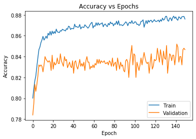

```python
plt.plot(history_best.history['accuracy'])
plt.plot(history_best.history['val_accuracy'])
plt.title('Accuracy vs Epochs')
plt.ylabel('Accuracy')
plt.xlabel('Epoch')
plt.legend(['Train', 'Validation'], loc='lower right')
plt.show()
```

Looking at this chart, it doesn't appear to have reached its true plateau for either the training or validation sets. Let's let this model run a little longer.

```
Train on 6750 samples, validate on 750 samples
6750/6750 - 1s - loss: 0.4752 - accuracy: 0.7997 - val_loss: 0.4765 - val_accuracy: 0.7920
6750/6750 - 0s - loss: 0.4270 - accuracy: 0.8151 - val_loss: 0.4242 - val_accuracy: 0.8213
6750/6750 - 0s - loss: 0.3881 - accuracy: 0.8369 - val_loss: 0.3933 - val_accuracy: 0.8293
6750/6750 - 0s - loss: 0.3730 - accuracy: 0.8452 - val_loss: 0.3942 - val_accuracy: 0.8253
6750/6750 - 0s - loss: 0.3681 - accuracy: 0.8449 - val_loss: 0.3813 - val_accuracy: 0.8333
6750/6750 - 0s - loss: 0.3652 - accuracy: 0.8476 - val_loss: 0.3899 - val_accuracy: 0.8333
6750/6750 - 0s - loss: 0.3618 - accuracy: 0.8502 - val_loss: 0.3843 - val_accuracy: 0.8320
6750/6750 - 0s - loss: 0.3591 - accuracy: 0.8514 - val_loss: 0.3780 - val_accuracy: 0.8320
6750/6750 - 0s - loss: 0.3563 - accuracy: 0.8501 - val_loss: 0.3878 - val_accuracy: 0.8333
6750/6750 - 0s - loss: 0.3538 - accuracy: 0.8544 - val_loss: 0.3896 - val_accuracy: 0.8333
6750/6750 - 0s - loss: 0.3532 - accuracy: 0.8551 - val_loss: 0.3789 - val_accuracy: 0.8333
6750/6750 - 0s - loss: 0.3512 - accuracy: 0.8538 - val_loss: 0.3882 - val_accuracy: 0.8360
6750/6750 - 0s - loss: 0.3502 - accuracy: 0.8561 - val_loss: 0.3898 - val_accuracy: 0.8333
6750/6750 - 0s - loss: 0.3481 - accuracy: 0.8560 - val_loss: 0.3839 - val_accuracy: 0.8387
6750/6750 - 0s - loss: 0.3470 - accuracy: 0.8567 - val_loss: 0.3868 - val_accuracy: 0.8347
6750/6750 - 0s - loss: 0.3460 - accuracy: 0.8593 - val_loss: 0.3888 - val_accuracy: 0.8373
6750/6750 - 0s - loss: 0.3441 - accuracy: 0.8576 - val_loss: 0.3984 - val_accuracy: 0.8320
6750/6750 - 0s - loss: 0.3440 - accuracy: 0.8615 - val_loss: 0.3737 - val_accuracy: 0.8453
6750/6750 - 0s - loss: 0.3418 - accuracy: 0.8587 - val_loss: 0.3774 - val_accuracy: 0.8413
6750/6750 - 0s - loss: 0.3401 - accuracy: 0.8618 - val_loss: 0.3769 - val_accuracy: 0.8373
6750/6750 - 0s - loss: 0.3411 - accuracy: 0.8633 - val_loss: 0.3820 - val_accuracy: 0.8413
6750/6750 - 0s - loss: 0.3384 - accuracy: 0.8615 - val_loss: 0.3801 - val_accuracy: 0.8347
6750/6750 - 0s - loss: 0.3394 - accuracy: 0.8618 - val_loss: 0.3801 - val_accuracy: 0.8467
6750/6750 - 0s - loss: 0.3399 - accuracy: 0.8628 - val_loss: 0.3981 - val_accuracy: 0.8320
6750/6750 - 0s - loss: 0.3373 - accuracy: 0.8630 - val_loss: 0.3787 - val_accuracy: 0.8293
6750/6750 - 0s - loss: 0.3349 - accuracy: 0.8644 - val_loss: 0.3801 - val_accuracy: 0.8347
6750/6750 - 0s - loss: 0.3355 - accuracy: 0.8641 - val_loss: 0.3723 - val_accuracy: 0.8440
6750/6750 - 0s - loss: 0.3355 - accuracy: 0.8625 - val_loss: 0.3736 - val_accuracy: 0.8453
6750/6750 - 0s - loss: 0.3348 - accuracy: 0.8641 - val_loss: 0.3918 - val_accuracy: 0.8333
6750/6750 - 0s - loss: 0.3334 - accuracy: 0.8646 - val_loss: 0.3860 - val_accuracy: 0.8347
6750/6750 - 0s - loss: 0.3335 - accuracy: 0.8661 - val_loss: 0.3932 - val_accuracy: 0.8320
6750/6750 - 0s - loss: 0.3318 - accuracy: 0.8674 - val_loss: 0.3749 - val_accuracy: 0.8427
6750/6750 - 0s - loss: 0.3309 - accuracy: 0.8693 - val_loss: 0.3707 - val_accuracy: 0.8440
6750/6750 - 0s - loss: 0.3299 - accuracy: 0.8652 - val_loss: 0.3907 - val_accuracy: 0.8373
6750/6750 - 0s - loss: 0.3308 - accuracy: 0.8667 - val_loss: 0.3750 - val_accuracy: 0.8453
6750/6750 - 0s - loss: 0.3297 - accuracy: 0.8664 - val_loss: 0.3689 - val_accuracy: 0.8467
6750/6750 - 0s - loss: 0.3293 - accuracy: 0.8662 - val_loss: 0.3794 - val_accuracy: 0.8373
6750/6750 - 0s - loss: 0.3290 - accuracy: 0.8671 - val_loss: 0.3856 - val_accuracy: 0.8307
6750/6750 - 0s - loss: 0.3268 - accuracy: 0.8665 - val_loss: 0.3984 - val_accuracy: 0.8253
```

[output cut: 346 more lines]

```
6750/6750 - 0s - loss: 0.2965 - accuracy: 0.8859 - val_loss: 0.4686 - val_accuracy: 0.8427
6750/6750 - 0s - loss: 0.2965 - accuracy: 0.8861 - val_loss: 0.5118 - val_accuracy: 0.8347
6750/6750 - 0s - loss: 0.2938 - accuracy: 0.8901 - val_loss: 0.5371 - val_accuracy: 0.8253
6750/6750 - 0s - loss: 0.2898 - accuracy: 0.8867 - val_loss: 0.4683 - val_accuracy: 0.8320
6750/6750 - 0s - loss: 0.2912 - accuracy: 0.8907 - val_loss: 0.4928 - val_accuracy: 0.8320
6750/6750 - 0s - loss: 0.2918 - accuracy: 0.8892 - val_loss: 0.4432 - val_accuracy: 0.8160
6750/6750 - 0s - loss: 0.2943 - accuracy: 0.8868 - val_loss: 0.4612 - val_accuracy: 0.8213
6750/6750 - 0s - loss: 0.2867 - accuracy: 0.8908 - val_loss: 0.4587 - val_accuracy: 0.8333
6750/6750 - 0s - loss: 0.2905 - accuracy: 0.8893 - val_loss: 0.4755 - val_accuracy: 0.8253
6750/6750 - 0s - loss: 0.2943 - accuracy: 0.8877 - val_loss: 0.4534 - val_accuracy: 0.8387
6750/6750 - 0s - loss: 0.2962 - accuracy: 0.8899 - val_loss: 0.5010 - val_accuracy: 0.8280
6750/6750 - 0s - loss: 0.2963 - accuracy: 0.8904 - val_loss: 0.5293 - val_accuracy: 0.8320
6750/6750 - 0s - loss: 0.2956 - accuracy: 0.8834 - val_loss: 0.5067 - val_accuracy: 0.8400
6750/6750 - 0s - loss: 0.2954 - accuracy: 0.8898 - val_loss: 0.6174 - val_accuracy: 0.8293
6750/6750 - 0s - loss: 0.2906 - accuracy: 0.8881 - val_loss: 0.4799 - val_accuracy: 0.8267
```

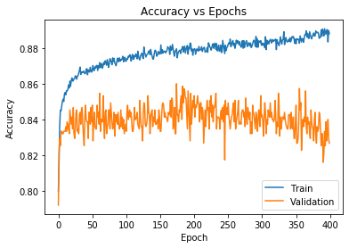

```python
best = buildModel("rmsprop", 3, 32, 0)
history_best = best.fit(
    X_train,
    y_train,
    batch_size = 16,
    validation_split=0.1,
    epochs=400,
    verbose=2
)

plt.plot(history_best.history['accuracy'])
plt.plot(history_best.history['val_accuracy'])
plt.title('Accuracy vs Epochs')
plt.ylabel('Accuracy')
plt.xlabel('Epoch')
plt.legend(['Train', 'Validation'], loc='lower right')
plt.show()
```

Alright, never mind. It looks like epochs further than 200 just cause more overfitting in this case.

### Model Improvement: Neural Network model with balanced data

```python
sm = SMOTE(sampling_strategy=1, k_neighbors=5, random_state=1)
X_train_over, y_train_over = sm.fit_resample(X_train, y_train)

model = KerasRegressor(build_fn = buildModel)

parameters = {
    'batch_size': [16, 32],
    'optimizer': ['adam', 'rmsprop'],
    'hidden_layers': [2, 3, 4],
    'hidden_layer_size': [16, 32, 64],
    'dropout': [0, 0.5]
}

grid_search = GridSearchCV(estimator = model,
                           param_grid = parameters,
                           scoring = 'neg_mean_absolute_error',
                           cv = 5)
grid_search = grid_search.fit(X_train_over, y_train_over, verbose = 0)
```

```python
grid_search.best_params_
```

```
{'batch_size': 16,
 'dropout': 0,
 'hidden_layer_size': 64,
 'hidden_layers': 3,
 'optimizer': 'adam'}
```

```python
best = buildModel("adam", 3, 64, 0)

history_best = best.fit(
    X_train_over,
    y_train_over,
    batch_size = 16,
    validation_split=0.1,
    epochs=150,
    verbose=2
)
```

```
Train on 10769 samples, validate on 1197 samples
10769/10769 - 1s - loss: 0.5960 - accuracy: 0.6760 - val_loss: 0.5610 - val_accuracy: 0.7059
10769/10769 - 1s - loss: 0.5088 - accuracy: 0.7486 - val_loss: 0.6297 - val_accuracy: 0.6675
10769/10769 - 1s - loss: 0.4724 - accuracy: 0.7711 - val_loss: 0.5285 - val_accuracy: 0.7293
10769/10769 - 1s - loss: 0.4607 - accuracy: 0.7826 - val_loss: 0.5214 - val_accuracy: 0.7201
10769/10769 - 1s - loss: 0.4500 - accuracy: 0.7876 - val_loss: 0.5382 - val_accuracy: 0.7160
10769/10769 - 1s - loss: 0.4389 - accuracy: 0.7956 - val_loss: 0.4656 - val_accuracy: 0.7686
10769/10769 - 1s - loss: 0.4351 - accuracy: 0.7984 - val_loss: 0.5342 - val_accuracy: 0.7168
10769/10769 - 1s - loss: 0.4268 - accuracy: 0.7989 - val_loss: 0.5093 - val_accuracy: 0.7552
10769/10769 - 1s - loss: 0.4235 - accuracy: 0.8039 - val_loss: 0.4908 - val_accuracy: 0.7527
10769/10769 - 1s - loss: 0.4171 - accuracy: 0.8077 - val_loss: 0.4493 - val_accuracy: 0.7769
10769/10769 - 1s - loss: 0.4118 - accuracy: 0.8088 - val_loss: 0.5239 - val_accuracy: 0.7368
10769/10769 - 1s - loss: 0.4060 - accuracy: 0.8143 - val_loss: 0.4750 - val_accuracy: 0.7519
10769/10769 - 1s - loss: 0.3999 - accuracy: 0.8156 - val_loss: 0.4269 - val_accuracy: 0.7978
10769/10769 - 1s - loss: 0.3962 - accuracy: 0.8173 - val_loss: 0.3979 - val_accuracy: 0.8212
10769/10769 - 1s - loss: 0.3890 - accuracy: 0.8194 - val_loss: 0.3585 - val_accuracy: 0.8338
10769/10769 - 1s - loss: 0.3867 - accuracy: 0.8215 - val_loss: 0.4307 - val_accuracy: 0.8095
10769/10769 - 1s - loss: 0.3804 - accuracy: 0.8216 - val_loss: 0.3634 - val_accuracy: 0.8396
10769/10769 - 1s - loss: 0.3761 - accuracy: 0.8266 - val_loss: 0.5305 - val_accuracy: 0.7343
10769/10769 - 1s - loss: 0.3709 - accuracy: 0.8275 - val_loss: 0.3909 - val_accuracy: 0.8195
10769/10769 - 1s - loss: 0.3646 - accuracy: 0.8318 - val_loss: 0.4509 - val_accuracy: 0.7803
10769/10769 - 1s - loss: 0.3595 - accuracy: 0.8330 - val_loss: 0.2921 - val_accuracy: 0.8780
10769/10769 - 1s - loss: 0.3556 - accuracy: 0.8382 - val_loss: 0.4308 - val_accuracy: 0.7937
10769/10769 - 1s - loss: 0.3512 - accuracy: 0.8403 - val_loss: 0.3112 - val_accuracy: 0.8580
10769/10769 - 1s - loss: 0.3445 - accuracy: 0.8428 - val_loss: 0.3458 - val_accuracy: 0.8488
10769/10769 - 1s - loss: 0.3433 - accuracy: 0.8453 - val_loss: 0.3542 - val_accuracy: 0.8396
10769/10769 - 1s - loss: 0.3345 - accuracy: 0.8481 - val_loss: 0.4178 - val_accuracy: 0.7978
10769/10769 - 1s - loss: 0.3323 - accuracy: 0.8501 - val_loss: 0.2306 - val_accuracy: 0.9231
10769/10769 - 1s - loss: 0.3253 - accuracy: 0.8522 - val_loss: 0.2585 - val_accuracy: 0.9023
10769/10769 - 1s - loss: 0.3213 - accuracy: 0.8543 - val_loss: 0.2341 - val_accuracy: 0.9248
10769/10769 - 1s - loss: 0.3175 - accuracy: 0.8594 - val_loss: 0.4063 - val_accuracy: 0.8154
10769/10769 - 1s - loss: 0.3132 - accuracy: 0.8610 - val_loss: 0.3336 - val_accuracy: 0.8496
10769/10769 - 1s - loss: 0.3065 - accuracy: 0.8615 - val_loss: 0.1828 - val_accuracy: 0.9348
10769/10769 - 1s - loss: 0.3070 - accuracy: 0.8610 - val_loss: 0.3872 - val_accuracy: 0.8262
10769/10769 - 1s - loss: 0.2998 - accuracy: 0.8646 - val_loss: 0.3015 - val_accuracy: 0.8830
10769/10769 - 1s - loss: 0.2945 - accuracy: 0.8695 - val_loss: 0.2781 - val_accuracy: 0.8855
10769/10769 - 1s - loss: 0.2883 - accuracy: 0.8710 - val_loss: 0.3154 - val_accuracy: 0.8722
10769/10769 - 1s - loss: 0.2895 - accuracy: 0.8714 - val_loss: 0.2469 - val_accuracy: 0.9039
10769/10769 - 1s - loss: 0.2816 - accuracy: 0.8746 - val_loss: 0.3331 - val_accuracy: 0.8713
10769/10769 - 1s - loss: 0.2837 - accuracy: 0.8758 - val_loss: 0.2234 - val_accuracy: 0.9256
```

[output cut: 96 more lines]

```
10769/10769 - 1s - loss: 0.0963 - accuracy: 0.9627 - val_loss: 0.3203 - val_accuracy: 0.8889
10769/10769 - 1s - loss: 0.0990 - accuracy: 0.9614 - val_loss: 0.1840 - val_accuracy: 0.9457
10769/10769 - 1s - loss: 0.0966 - accuracy: 0.9621 - val_loss: 0.1925 - val_accuracy: 0.9382
10769/10769 - 1s - loss: 0.1003 - accuracy: 0.9602 - val_loss: 0.2140 - val_accuracy: 0.9265
10769/10769 - 1s - loss: 0.0938 - accuracy: 0.9629 - val_loss: 0.2646 - val_accuracy: 0.9006
10769/10769 - 1s - loss: 0.1016 - accuracy: 0.9603 - val_loss: 0.1850 - val_accuracy: 0.9440
10769/10769 - 1s - loss: 0.1018 - accuracy: 0.9621 - val_loss: 0.3994 - val_accuracy: 0.8546
10769/10769 - 1s - loss: 0.0998 - accuracy: 0.9600 - val_loss: 0.1618 - val_accuracy: 0.9524
10769/10769 - 1s - loss: 0.0983 - accuracy: 0.9613 - val_loss: 0.2390 - val_accuracy: 0.9282
10769/10769 - 1s - loss: 0.0925 - accuracy: 0.9643 - val_loss: 0.1666 - val_accuracy: 0.9449
10769/10769 - 1s - loss: 0.0871 - accuracy: 0.9665 - val_loss: 0.2423 - val_accuracy: 0.9206
10769/10769 - 1s - loss: 0.0937 - accuracy: 0.9624 - val_loss: 0.2581 - val_accuracy: 0.9098
10769/10769 - 1s - loss: 0.0863 - accuracy: 0.9674 - val_loss: 0.1806 - val_accuracy: 0.9340
10769/10769 - 1s - loss: 0.1043 - accuracy: 0.9613 - val_loss: 0.2206 - val_accuracy: 0.9307
10769/10769 - 1s - loss: 0.0906 - accuracy: 0.9649 - val_loss: 0.1801 - val_accuracy: 0.9415
```

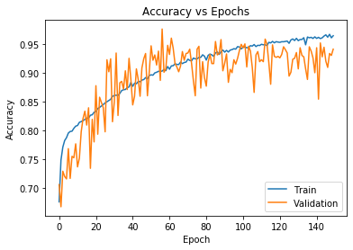

```python
plt.plot(history_best.history['accuracy'])
plt.plot(history_best.history['val_accuracy'])
plt.title('Accuracy vs Epochs')
plt.ylabel('Accuracy')
plt.xlabel('Epoch')
plt.legend(['Train', 'Validation'], loc='lower right')
plt.show()
```

This is encouraging! Maybe we let it run a little too long (since validation accuracy stopped going up around Epoch 100), but it did reach a quite high accuracy of nearly 95%. Too good to be true?

We're finally ready to see how well this does against the unseen test data.

## Final Model

```python
y_pred = np.round(best.predict(X_test))
#Output is a probability, so rounding sets it to whichever is closer, 0 or 1.

print(f"Accuracy: {accuracy_score(y_test, y_pred):>.2%}")
print(f"Recall: {recall_score(y_test, y_pred):>.2%}")
print(f"Precision: {precision_score(y_test, y_pred):>.2%}")
print(confusion_matrix(y_test, y_pred))
```

```
Accuracy: 79.88%
Recall: 51.15%
Precision: 51.65%
[[1731  249]
 [ 254  266]]
```

I have to say this was a little disappointing. Our best-performing model (Adam optimizer, 3 hidden layers of 64 nodes, and no dropout) still only reached 80% accuracy.

It is perhaps better than the "no exiters" model, despite the same accuracy. The model was fairly balanced between recall and precision, where recall is the percent of positive cases we detected and precision is the rate that a predicted positive was correct. So theoretically these values would adjust even if we have an unusually large or small number of exiters in a six-month period. The "no exiters" model would predict a static 20% loss even in those cases.

## Actionable Insights and Recommendations

**What recommedations would you suggest to the bank?**

- The model is not yet good enough to be able to suggest actions for individual customers, such as marketing or promotion efforts to retain potential exiters.
- The model might be good enough to help predict overall churn, which could be used to set budgets six months from now.
- The drawback of a neural net vs. other models is that feature importance or correlation coefficients are hidden inside the inner workings of the model. More advanced techniques would be required to determine how much each of the features are actually mattering for calculating the predictions. This data might be helpful to t he bank for developing policies on dealing with customers of different genders or geography.